## 1. INTRODUCTION

### 1.1. Aim of the Project

In this project, it is aimed to visualize the main insights about Covid-19 pandemic. Starting from *‘2020-01-01’* , pandemic data from all countries is recorded in the data set. The data set is very useful and gives wide information about status of countries in pandemic period. There are information about cases, deaths, reproduction rates, intensive care unit(icu) patients, tests, positiveness rates, vaccinations etc.

### 1.2. Information About Data Set

The dataset is extracted from [Our World in Data](https://ourworldindata.org/coronavirus-source-data) and it can be downloaded from [GitHub Covid-19 Repository](https://github.com/owid/covid-19-data/tree/master/public/data).It contains 59 columns and 86,118 rows giving information about each country. The head of data set is provided below:

Data Set with First 5 Rows

|  | iso_code | continent | location | date | total_cases | new_cases | new_cases_smoothed | total_deaths | new_deaths | new_deaths_smoothed | total_cases_per_million | new_cases_per_million | new_cases_smoothed_per_million | total_deaths_per_million | new_deaths_per_million | new_deaths_smoothed_per_million | reproduction_rate | icu_patients | icu_patients_per_million | hosp_patients | hosp_patients_per_million | weekly_icu_admissions | weekly_icu_admissions_per_million | weekly_hosp_admissions | weekly_hosp_admissions_per_million | new_tests | total_tests | total_tests_per_thousand | new_tests_per_thousand | … |
| --- | --- | --- | --- | --- | --- | --- | --- | --- | --- | --- | --- | --- | --- | --- | --- | --- | --- | --- | --- | --- | --- | --- | --- | --- | --- | --- | --- | --- | --- | --- |
| 1 | AFG | Asia | Afghanistan | 2020-02-24 | 1 | 1 | NA | NA | NA | NA | 0.03 | 0.03 | NA | NA | NA | NA | NA | NA | NA | NA | NA | NA | NA | NA | NA | NA | NA | NA | NA | … |
| 2 | AFG | Asia | Afghanistan | 2020-02-25 | 1 | 0 | NA | NA | NA | NA | 0.03 | 0.00 | NA | NA | NA | NA | NA | NA | NA | NA | NA | NA | NA | NA | NA | NA | NA | NA | NA | … |
| 3 | AFG | Asia | Afghanistan | 2020-02-26 | 1 | 0 | NA | NA | NA | NA | 0.03 | 0.00 | NA | NA | NA | NA | NA | NA | NA | NA | NA | NA | NA | NA | NA | NA | NA | NA | NA | … |
| 4 | AFG | Asia | Afghanistan | 2020-02-27 | 1 | 0 | NA | NA | NA | NA | 0.03 | 0.00 | NA | NA | NA | NA | NA | NA | NA | NA | NA | NA | NA | NA | NA | NA | NA | NA | NA | … |
| 5 | AFG | Asia | Afghanistan | 2020-02-28 | 1 | 0 | NA | NA | NA | NA | 0.03 | 0.00 | NA | NA | NA | NA | NA | NA | NA | NA | NA | NA | NA | NA | NA | NA | NA | NA | NA | … |

## 2. ANALYSIS ABOUT COVID-19

### The Situation of Covid-19 Pandemic in the World

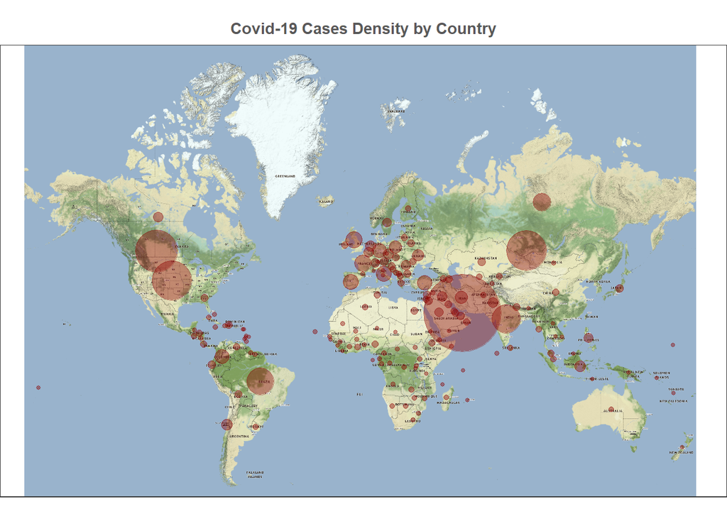

### Total Case and New Cases Trend

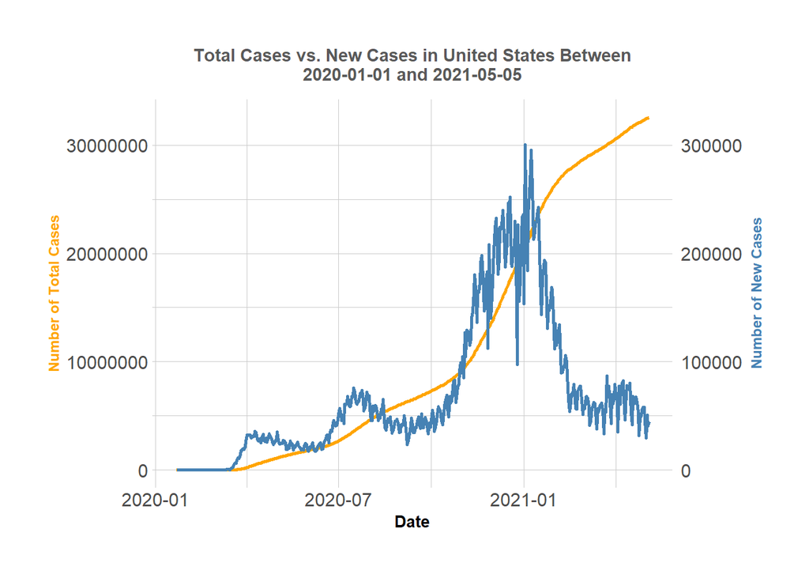